# BIOL606_hw_Lecture14_Hastings

2025-04-08

# Task 1

### Question 1: Using only the data for the ‘hot’ temperature treatment, compare the shell growth of the Crab and No-Crab treatment levels, using a permutation routine.

Your code should load the data, carry out 9999 permutations (+1 original value), calculate the permuted difference in medians, and 95% confidence interval derived from the permuted differences.

```r
# Subset the data to only include the 'hot' temperature treatment and remove rows with missing ShellGrowth.mg values.
hot_snail <- snail |>
  filter(Temperature == 'hot', !is.na(ShellGrowth.mg))

# Set the seed for reproducibility.
set.seed(472)

# Set up the number of permutations (9999 permutations + 1 observed value) and pre-allocate a vector.
n_perms <- 9999
perm_diffs <- numeric(n_perms + 1)

# Compute the observed difference in medians (actual group difference in the unshuffled data).
perm_diffs[1] <- with(hot_snail,
  median(ShellGrowth.mg[Crab == 'crab']) -
    median(ShellGrowth.mg[Crab == 'no crab'])
)

# Create the null distribution by randomly shuffling the shell growth values.
# This simulates what kind of differences we would expect if there were no treatment effect.
for (i in 2:(n_perms + 1)) {
  shuffled_growth <- sample(hot_snail$ShellGrowth.mg)  # Shuffle response variable.

  # Recalculate the difference in medians for the shuffled data.
  perm_diffs[i] <- with(hot_snail,
    median(shuffled_growth[Crab == 'crab']) -
      median(shuffled_growth[Crab == 'no crab'])
  )
}

# Calculate a 95% confidence interval from the permutation distribution.
conf_int <- quantile(perm_diffs, probs = c(0.025, 0.975))

# Compute the two-tailed p-value.
# This is the proportion of permuted differences as or more extreme than the observed one.
p_val <- mean(abs(perm_diffs) >= abs(perm_diffs[1]))

# Display the results.
cat('Observed difference in medians:', perm_diffs[1], '\n')
```

```
## Observed difference in medians: -13.9095
```

```r
cat('95% confidence interval:', conf_int[1], 'to', conf_int[2], '\n')
```

```
## 95% confidence interval: -7.7275 to 7.7275
```

```r
cat('Two-tailed p-value:', p_val, '\n')
```

```
## Two-tailed p-value: 2e-04
```

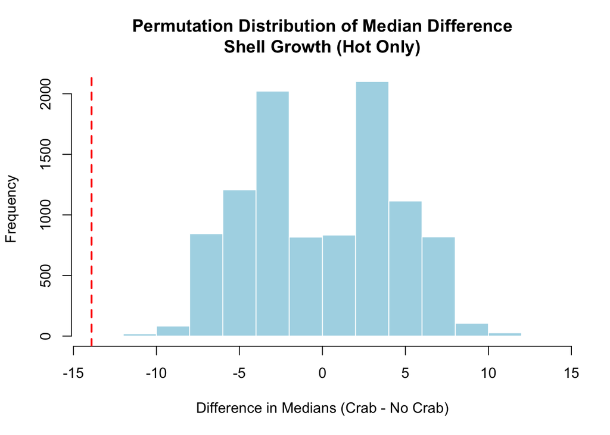

```r
# Plot the null distribution with the observed difference marked.
hist(perm_diffs,
     main = 'Permutation Distribution of Median Difference\nShell Growth (Hot Only)',
     xlab = 'Difference in Medians (Crab - No Crab)',
     col = 'lightblue',
     border = 'white')
abline(v = perm_diffs[1], col = 'red', lwd = 2, lty = 2)
```

### Question 2: Is the observed difference in median growth of the two groups significantly different than what we would expect by random chance (i.e. if the two groups weren’t different)?

Yes, the observed difference in median shell growth between Crab and No-Crab treatments under hot temperature is significantly different than what we would expect by random chance.

- Observed difference: –13.91 mg
- 95% CI from permutation: –7.73 to 7.73
- Two-tailed p-value: 0.0002

The observed value lies outside the 95% confidence interval and the p-value is far less than 0.05.

We reject the null hypothesis.

# Task 2

### Question 3: Use the boot() and boot.ci() functions to estimate the mean shell growth and BCa 95% confidence intervals for the Ambient temperature, No-Crab treatment group, based on 9999 resamples.

Use the boot() and boot.ci() functions to estimate the mean shell growth and BCa 95% confidence intervals for the Ambient temperature, No-Crab treatment group, based on 9999 resamples.

```r
# Subset the data for one specific treatment group.
# - Temperature is 'ambient'
# - No crab exposure
# - Shell growth measurements are not missing
ambient_nocrab <- snail |>
  filter(
    Temperature == 'ambient',
    Crab == 'no crab',
    !is.na(ShellGrowth.mg)
  )

# Define the function that calculates the mean to be used in the bootstrap.
mean_fun <- function(data, indices) {
  # Use the indices to randomly sample from the data (with replacement).
  resampled_data <- data[indices]

  # Calculate and return the mean of this resample and store as part of the bootstrap distribution.
  return(mean(resampled_data))
}

# Run the bootstrap. Resample the data 9999 times and applies the mean_fun() each time.
set.seed(472)  # Set a random seed.
boot_result <- boot(
  data = ambient_nocrab$ShellGrowth.mg,  # The shell growth values to sample from.
  statistic = mean_fun,                  # Function to compute the mean.
  R = 9999                               # Number of resamples (excluding the original sample).
)

# View the results of the bootstrap procedure.
boot_result
```

```
##
## ORDINARY NONPARAMETRIC BOOTSTRAP
##
##
## Call:
## boot(data = ambient_nocrab$ShellGrowth.mg, statistic = mean_fun,
##     R = 9999)
##
##
## Bootstrap Statistics :
##     original      bias    std. error
## t1* 65.02139 -0.01024272    4.998674
```

```r
# Calculate a 95% confidence interval using the BCa method.
boot_ci <- boot.ci(
  boot.out = boot_result,  # The output from the boot() function.
  type = 'bca'             # Request the BCa interval.
)

# Print the BCa confidence interval.
boot_ci
```

```
## BOOTSTRAP CONFIDENCE INTERVAL CALCULATIONS
## Based on 9999 bootstrap replicates
##
## CALL :
## boot.ci(boot.out = boot_result, type = "bca")
##
## Intervals :
## Level       BCa
## 95%   (55.96, 75.59 )
## Calculations and Intervals on Original Scale
```